# Salmon Counts at Bonneville Dam

Corinna Hong

February 18, 2020

Bonneville Lock and Dam’s first powerhouse was completed in 1938 on the Columbia River in Oregon to provide hydropower to the Pacific Northwest (U.S. Army Corps of Engineers, n.d.). This project visualizes changes in steelhead salmon passage counts across Bonneville Dam from 1940 - 2019. It first looks at changes in daily counts, then changes in monthly and yearly counts over the same time period.

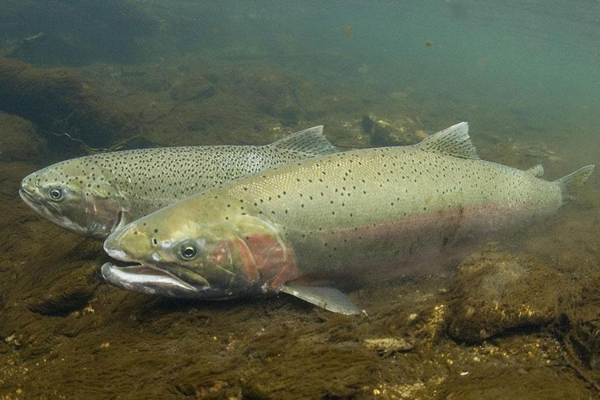

Steelhead in river.  
Steelhead Trout (NOAA Fisheries). (n.d.). Retrieved from https://www.fisheries.noaa.gov/species/steelhead-trout

```r
# Load packages

library(tidyverse)
library(janitor)
library(lubridate)
library(here)
library(paletteer)
```

```r
# Read in data

salmon <- read_csv("cbr_fish_passage_bonneville_allyrs_steelhead.csv") %>%
  clean_names()
```

```r
# Wrangle data for daily counts

salmon_day <- salmon %>%
  unite(year, mm_dd, col = "date", sep = "-") %>% # unite year and mm_dd column and separate values with "-"
  mutate(yr_mo_day = lubridate::parse_date_time(date, "ydm")) %>% # format date
  drop_na(yr_mo_day, value) # drop NAs from value column
```

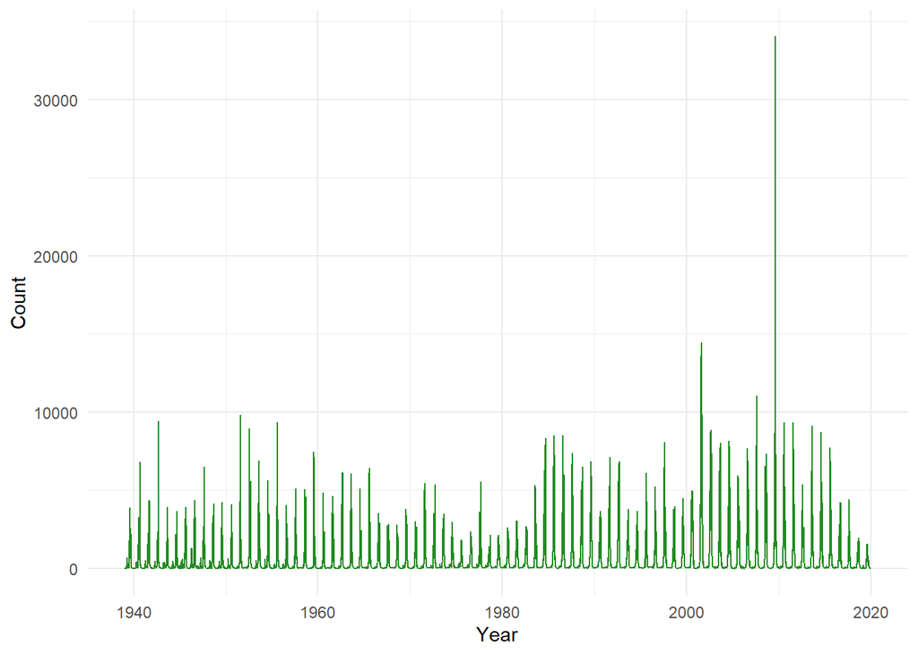

**Figure 1. Daily Steelhead Salmon Passage at Bonneville Dam (1940 - 2019).** Time-seris plot showing daily changes in steelhead salmon counts at Bonneville Dam. Data accessed at: http://www.cbr.washington.edu/dart/query/adult_graph_text

```r
# Create graph of daily counts

salmon_day_gg <- ggplot(data = salmon_day, aes(x = yr_mo_day, y = value)) +
  geom_line(color = "forestgreen") +
  labs (x = "Year", y = "Count") +
  scale_y_continuous() +
  theme_minimal()

salmon_day_gg
```

A time-series plot of daily steelhead passage shows changes in the number of steelhead throughout each year. Each year contains a peak where passage counts are the highest. The pattern suggests that passage counts have some seasonality; counts start off low at the beginning of the year, slowly increase until the reach a peak, then being to decrease again.

```r
# Wrangle data for monthly counts

salmon_parse <- salmon_day %>%
  mutate(month = month(yr_mo_day, label = TRUE)) %>% # pull month from yr_mo_day, label = true gives months 3 letter label
  mutate(year = year(yr_mo_day))

salmon_monthly <- salmon_parse %>%
  group_by(year, month) %>%
  summarize(total = sum(value)) # Add values column by month for each year
```

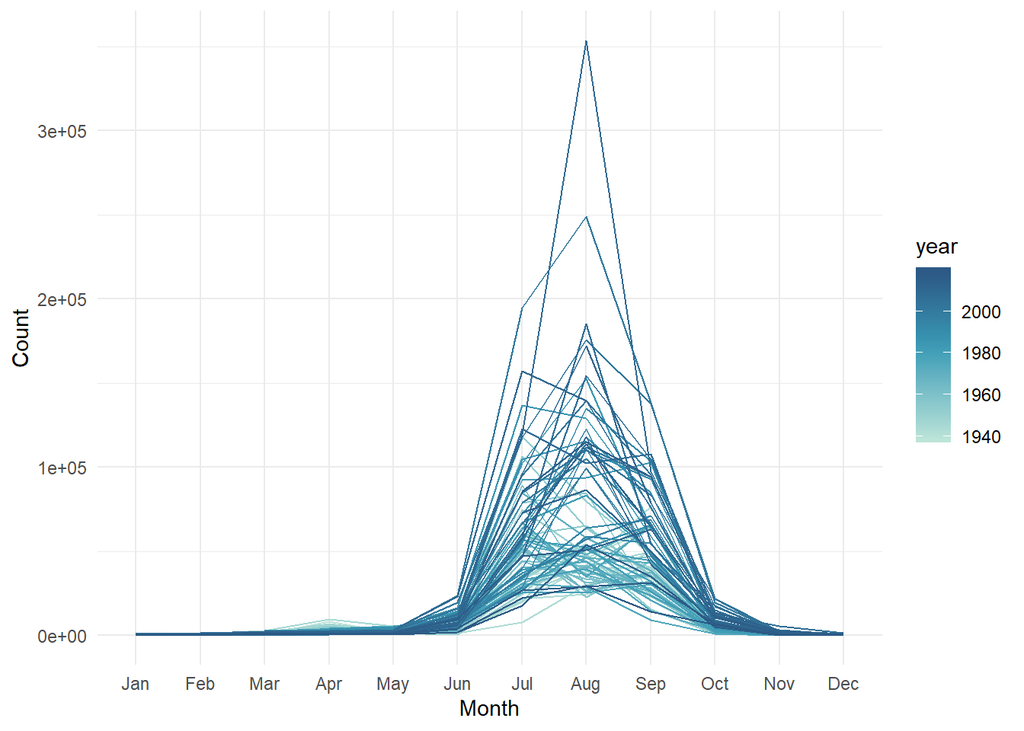

**Figure 2. Monthly Steelhead Salmon Passage at Bonneville Dam (1940 - 2019).** Time-seris plot showing monthly changes in steelhead salmon counts at Bonneville Dam each year. Counts were totaled by month then plotted for each year. Data accessed at: http://www.cbr.washington.edu/dart/query/adult_graph_text

```r
# Graph data for monthly counts

salmon_month_gg <- ggplot(salmon_monthly, aes(x = month, y = total, group = year)) + # separate by year
  geom_line(aes(color = year)) + # color by year
  labs (x = "Month", y = "Count") +
  scale_color_paletteer_c("ggthemes::Blue-Teal") + # change color palette
  scale_y_continuous() +
  theme_minimal()

salmon_month_gg
```

```r
# Wrangle data for yearly counts

salmon_yearly <- salmon_parse %>%
  group_by(year) %>%
  summarize(total = sum(value))
```

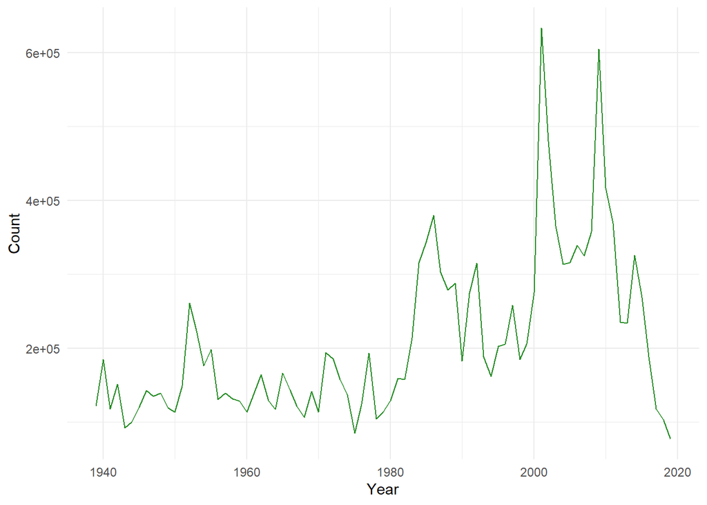

**Figure 3. Annual Steelhead Salmon Passage at Bonneville Dam (1940 - 2019).** Time-seris plot showing annual changes in steelhead salmon counts at Bonneville Dam. Counts were totaled by year. Data accessed at: http://www.cbr.washington.edu/dart/query/adult_graph_text

```r
# Graph data for yearly counts

salmon_year_gg <- ggplot(salmon_yearly, aes(x = year, y = total)) +
  geom_line(color = "forestgreen") +
  labs (x = "Year", y = "Count") +
  scale_y_continuous() +
  theme_minimal()

salmon_year_gg
```

**References**  
Columbia River DART, Columbia Basin Research, University of Washington. (2019). Adult Passage Graphics & Text. Available from http://www.cbr.washington.edu/dart/query/adult_graph_text

U.S. Army Corps of Engineers. (n.d). *Bonneville Lock & Dam*. Retrieved February 19, 2020, from https://www.nwp.usace.army.mil/bonneville/